# 08-Factor Analysis

# Exploratory factor analysis

This chapter is primarily based on

- Field, A., Miles J., & Field, Z. (2012): Discovering Statistics Using R. Sage Publications, **chapter 17**
- Malhotra, N. K.(2010). Marketing Research: An Applied Orientation (6th. ed.). Prentice Hall. **chapter 19**

## Introduction

In this chapter, we will focus on exploratory factor analysis.

Generally, factor analysis is a class of procedures used for data reduction or summarization. It is an **interdependence technique**, meaning that there is no distinction between dependent and independent variables and all variables are considered simultaneously. In **exploratory factor analysis**, specific hypotheses about how many factors will emerge, and what items these factors will comprise are not requires (as opposed to confirmatory factor analysis). Principal Components Analysis (PCA) is one of the most frequently used tequniques. The goals are …

- To identify underlying dimensions, or factors, that explain the correlations among a set of variables
- To identify a new, smaller set of uncorrelated variables to replace the original set of correlated variables in subsequent multivariate analysis (e.g., regression analysis, t-test, etc.)

To see what this means, let’s use a simple example. Say, you wanted to explain the motives underlying the purchasing of toothpaste. You come up with six items that represent different motives of purchasing toothpaste:

- **Item 1**: It is important to buy toothpaste that prevents cavities.
- **Item 2**: I like a toothpaste that gives shiny teeth.
- **Item 3**: A toothpaste should strengthen your gums.
- **Item 4**: I prefer a toothpaste that freshens breath.
- **Item 5**: Prevention of tooth decay should not be an important benefit offered by a toothpaste.
- **Item 6**: The most important consideration in buying a toothpaste is attractive teeth.

Let’s assume you collect data from 30 respondents and you use 7-point itemized rating scales to measure the extent of agreement to each of these statements. This is the data that you have collected:

```r
rm(factor_analysis)
factor_analysis <- read.table("https://raw.githubusercontent.com/IMSMWU/Teaching/master/MRDA2017/toothpaste.dat",
                          sep = "\t",
                          header = TRUE) #read in data
str(factor_analysis) #inspect data
```

```
'data.frame':   30 obs. of  6 variables:
 $ prevent_cavities: int  7 1 6 4 1 6 5 6 3 2 ...
 $ shiny_teeth     : int  3 3 2 5 2 3 3 4 4 6 ...
 $ strengthen_gum  : int  6 2 7 4 2 6 6 7 2 2 ...
 $ fresh_breath    : int  4 4 4 6 3 4 3 4 3 6 ...
 $ prevent_decay   : int  6 3 7 6 2 6 4 7 2 1 ...
 $ attract_teeth   : int  4 4 3 5 2 4 3 4 3 6 ...
```

```r
head(factor_analysis) #inspect data
```

|  | prevent_cavities | shiny_teeth | strengthen_gum | fresh_breath | prevent_decay | attract_teeth |
| --- | --- | --- | --- | --- | --- | --- |
| 1 | 7 | 3 | 6 | 4 | 6 | 4 |
| 2 | 1 | 3 | 2 | 4 | 3 | 4 |
| 3 | 6 | 2 | 7 | 4 | 7 | 3 |
| 4 | 4 | 5 | 4 | 6 | 6 | 5 |
| 5 | 1 | 2 | 2 | 3 | 2 | 2 |
| 6 | 6 | 3 | 6 | 4 | 6 | 4 |

A **construct** is a specific type of concept that exists at a higher level of abstraction than everyday concepts. In this example, the *perceived benefits* of toothpaste represent the construct that we would like to measure. The construct is unobservable (‘latent’) but it can be inferred from other measurable variables (items) that together comprise a scale (latent construct). A **multi-item scale** consists of multiple items, where an item is a single question or statement to be evaluated. In the above example, we use six items to measure the perceived benefits of toothpaste. If several items correlate highly, they might measure aspects of a common underlying dimension (a.k.a. factors). That is, specific patterns in the correlation matrix signal the existence of one or more factors underlying the data. Let’s inspect the correlation matrix using the `rcorr()` function from the `Hmisc` package.

```r
library("Hmisc")
rcorr(as.matrix(factor_analysis))
```

```
                 prevent_cavities shiny_teeth strengthen_gum fresh_breath prevent_decay attract_teeth
prevent_cavities             1.00       -0.05           0.87        -0.09          0.86          0.00
shiny_teeth                 -0.05        1.00          -0.16         0.57         -0.02          0.64
strengthen_gum               0.87       -0.16           1.00        -0.25          0.78         -0.02
fresh_breath                -0.09        0.57          -0.25         1.00          0.01          0.64
prevent_decay                0.86       -0.02           0.78         0.01          1.00          0.14
attract_teeth                0.00        0.64          -0.02         0.64          0.14          1.00

n= 30


P
                 prevent_cavities shiny_teeth strengthen_gum fresh_breath prevent_decay attract_teeth
prevent_cavities                  0.7800      0.0000         0.6508       0.0000        0.9826
shiny_teeth      0.7800                       0.4134         0.0010       0.9175        0.0001
strengthen_gum   0.0000           0.4134                     0.1868       0.0000        0.9245
fresh_breath     0.6508           0.0010      0.1868                      0.9725        0.0001
prevent_decay    0.0000           0.9175      0.0000         0.9725                     0.4723
attract_teeth    0.9826           0.0001      0.9245         0.0001       0.4723
```

You can see that some of the items correlate highly, while others don’t. Specifically, there appear to be two groups of items that correlate highly and that might represent underlying dimensions of the construct:

- Factor 1: Items 1, 3, 5
- Factor 2: Items 2, 4, 6

Going back to the specific wording of the items you can see that the first group of items (i.e., items 1,3,5) refer to the **health benefits**, while the second item group (i.e., items 2,4,6) refer to the **social benefits**. Imagine now, for example, you would like to include the above variables as explanatory variables in a regression model. Due to the high degree of correlation among the items, you are likely to run into problems of multicollinearity. Instead of omitting some of the items, you might try to combine highly correlated items into one variable. Another application could be when you are developing a new measurement scale for a construct and you wish to explore the underlying dimensions of this construct. In these applications, you need to make sure that the questions that you are asking actually relate to the construct that you intend to measure.

The goal of factor analysis is to explain the maximum amount of total variance in a correlation matrix by transforming the original variables into linear components. This means that the correlation matrix is broken down into a smaller set of dimensions. The generalized formal representation of the linear relationship between a latent factor *Y* and the set of variables can be written as:

$$\begin{equation}
Y_i=b_1X_{1i} + b_2X_{2i} + b_nX_{ni}+\epsilon_i
(\#eq:factor1)
\end{equation}$$

where X<sub>n</sub> represents the data that we have collected for the different variables. To make it more explicit, the equation could also be written as

$$\begin{equation}
Factor_i=b_1Variable_{1i} + b_2Variable_{2i} + b_nVariable_{ni}+\epsilon_i
(\#eq:factor2)
\end{equation}$$

where the dependent variable “Factor” refers to the factor score of person *i* on the underlying dimensions. In our case, the initial inspection suggested two underlying factors (i.e., health benefits and social benefits), so that we can construct two equations that describe both factors in terms of the variabels that we have measured:

$$\begin{equation}
Health_i=b_1X_{1i} + b_2X_{2i} + b_3X_{3i}+ b_4X_{4i}+ b_5X_{5i}+ b_6X_{6i}+\epsilon_i
(\#eq:factor3)
\end{equation}$$
$$\begin{equation}
Social_i=b_1X_{1i} + b_2X_{2i} + b_3X_{3i}+ b_4X_{4i}+ b_5X_{5i}+ b_6X_{6i}+\epsilon_i
(\#eq:factor4)
\end{equation}$$

where the b’s in each equation represent the **factor loadings**. You can see that both equations include the same set of predictors. However, their values in each equation will be different, depending on the importance of each variable to the respective factor. Once the factor loadings have been computed (we will see how this is done below), we can summarize them in a component matrix, which is usually denoted as `A`:

$$\mathbf{A} = \left[\begin{array}
{rrr}
0.93 & 0.25 \\
-0.30 & 0.80 \\
0.94 & 0.13 \\
-0.34 & 0.79 \\
0.87 & 0.35 \\
-0.18 & 0.87
\end{array}\right]$$

The linear relation between the factors and the factor loadings can also be shown in a graph, where each axis represents a factor and the variabels are placed on the coordinates according to the strength of the relationship between the variable and each factor. The greater the loading of variables on a factor, the more that factor explains relationships between those variables. You can also think of the factor loadings as the correlations between a factor and a variable.

[figure not shown]

The factor loadings may then be used to compute the two new variables (i.e., factor scores) representing the two underlying dimensions. Using a rather simplistic approach, the factor scores for person *i* could be computed by

$$\begin{equation}
\begin{split}
Health_i=& 0.93*preventCavities_{i} -0.3*shinyTeeth_{i} + 0.94*strengthenGum_{i}\\
&-0.34*freshBreath_{i} + 0.87*preventDecay_{i} - 0.18*attractTeeth_{i}
\end{split}
(\#eq:factor5)
\end{equation}$$
$$\begin{equation}
\begin{split}
Social_i=& 0.25*preventCavities_{i} + 0.80*shinyTeeth_{i} + 0.13*strengthenGum_{i}\\
&+ 0.79*freshBreath_{i}+ 0.35*preventDecay_{i}+ 0.87*attractTeeth_{i}
\end{split}
(\#eq:factor6)
\end{equation}$$

where the variable names are replaced by the values that were observed for respondent *i* to compute the factor scores for respondent *i*. This means that we have reduced the number of variables from six to two. Note that this is a rather simple approach that is intended to explain the underlying logic. However, that the resulting factor scores will depend on the measurement scales of the variables. If different measurment scales would be used, the resulting factor scores for different factors could not be compared. Thus, R will compute the factor scores using more sophisticated methods as we will see below.

## Steps in factor analysis

Now that we have a broad understanding of how factor analysis works, let’s use another example to go through the process of deriving factors step by step. In this section, we will use the R anxiety quesitonnaire from the book by Andy Field et al.. The questionnaire is intended to measure the various aspects of student’s anxiety towards learning R. It includes 23 items for which respondents are asked to indicate on a five-point Likert scale to what extent they agree with the respective statements. The questionnaire is shown in the following figure:

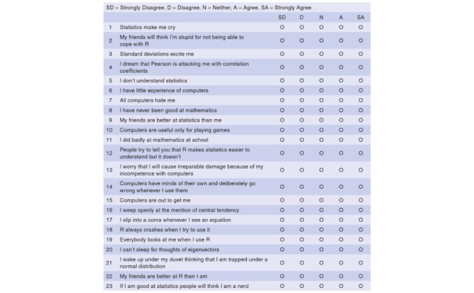

Let’s assume, we have collected data from 2,571 respondents and stored the results in the data set “raq.dat”.

```r
raq_data <- read.table("https://raw.githubusercontent.com/IMSMWU/Teaching/master/MRDA2017/raq.dat",
                          sep = "\t",
                          header = TRUE) #read in data
```

### Are the assumptions satisfied?

Since PCA is based the correlation between variables, the first step is to inspect the correlation matrix, which can be created using the `cor()` function.

```r
raq_matrix <- cor(raq_data)
round(raq_matrix,3)
```

```
       Q01    Q02    Q03    Q04    Q05    Q06    Q07    Q08    Q09    Q10    Q11    Q12    Q13    Q14    Q15    Q16    Q17    Q18    Q19    Q20
Q01  1.000 -0.099 -0.337  0.436  0.402  0.217  0.305  0.331 -0.092  0.214  0.357  0.345  0.355  0.338  0.246  0.499  0.371  0.347 -0.189  0.214
Q02 -0.099  1.000  0.318 -0.112 -0.119 -0.074 -0.159 -0.050  0.315 -0.084 -0.144 -0.195 -0.143 -0.165 -0.165 -0.168 -0.087 -0.164  0.203 -0.202
Q03 -0.337  0.318  1.000 -0.380 -0.310 -0.227 -0.382 -0.259  0.300 -0.193 -0.351 -0.410 -0.318 -0.371 -0.312 -0.419 -0.327 -0.375  0.342 -0.325
Q04  0.436 -0.112 -0.380  1.000  0.401  0.278  0.409  0.349 -0.125  0.216  0.369  0.442  0.344  0.351  0.334  0.416  0.383  0.382 -0.186  0.243
Q05  0.402 -0.119 -0.310  0.401  1.000  0.257  0.339  0.269 -0.096  0.258  0.298  0.347  0.302  0.315  0.261  0.395  0.310  0.322 -0.165  0.200
Q06  0.217 -0.074 -0.227  0.278  0.257  1.000  0.514  0.223 -0.113  0.322  0.328  0.313  0.466  0.402  0.360  0.244  0.282  0.513 -0.167  0.101
Q07  0.305 -0.159 -0.382  0.409  0.339  0.514  1.000  0.297 -0.128  0.284  0.345  0.423  0.442  0.441  0.391  0.389  0.391  0.501 -0.269  0.221
Q08  0.331 -0.050 -0.259  0.349  0.269  0.223  0.297  1.000  0.016  0.159  0.629  0.252  0.314  0.281  0.300  0.321  0.590  0.280 -0.159  0.175
Q09 -0.092  0.315  0.300 -0.125 -0.096 -0.113 -0.128  0.016  1.000 -0.134 -0.116 -0.167 -0.167 -0.122 -0.187 -0.189 -0.037 -0.150  0.249 -0.159
Q10  0.214 -0.084 -0.193  0.216  0.258  0.322  0.284  0.159 -0.134  1.000  0.271  0.246  0.302  0.255  0.295  0.291  0.218  0.293 -0.127  0.084
Q11  0.357 -0.144 -0.351  0.369  0.298  0.328  0.345  0.629 -0.116  0.271  1.000  0.335  0.423  0.325  0.365  0.369  0.587  0.373 -0.200  0.255
Q12  0.345 -0.195 -0.410  0.442  0.347  0.313  0.423  0.252 -0.167  0.246  0.335  1.000  0.489  0.433  0.332  0.408  0.333  0.493 -0.267  0.298
Q13  0.355 -0.143 -0.318  0.344  0.302  0.466  0.442  0.314 -0.167  0.302  0.423  0.489  1.000  0.450  0.342  0.358  0.408  0.533 -0.227  0.204
Q14  0.338 -0.165 -0.371  0.351  0.315  0.402  0.441  0.281 -0.122  0.255  0.325  0.433  0.450  1.000  0.380  0.418  0.354  0.498 -0.254  0.226
Q15  0.246 -0.165 -0.312  0.334  0.261  0.360  0.391  0.300 -0.187  0.295  0.365  0.332  0.342  0.380  1.000  0.454  0.373  0.343 -0.210  0.206
Q16  0.499 -0.168 -0.419  0.416  0.395  0.244  0.389  0.321 -0.189  0.291  0.369  0.408  0.358  0.418  0.454  1.000  0.410  0.422 -0.267  0.265
Q17  0.371 -0.087 -0.327  0.383  0.310  0.282  0.391  0.590 -0.037  0.218  0.587  0.333  0.408  0.354  0.373  0.410  1.000  0.376 -0.163  0.205
Q18  0.347 -0.164 -0.375  0.382  0.322  0.513  0.501  0.280 -0.150  0.293  0.373  0.493  0.533  0.498  0.343  0.422  0.376  1.000 -0.257  0.235
Q19 -0.189  0.203  0.342 -0.186 -0.165 -0.167 -0.269 -0.159  0.249 -0.127 -0.200 -0.267 -0.227 -0.254 -0.210 -0.267 -0.163 -0.257  1.000 -0.249
Q20  0.214 -0.202 -0.325  0.243  0.200  0.101  0.221  0.175 -0.159  0.084  0.255  0.298  0.204  0.226  0.206  0.265  0.205  0.235 -0.249  1.000
Q21  0.329 -0.205 -0.417  0.410  0.335  0.272  0.483  0.296 -0.136  0.193  0.346  0.441  0.374  0.399  0.300  0.421  0.363  0.430 -0.275  0.468
Q22 -0.104  0.231  0.204 -0.098 -0.133 -0.165 -0.168 -0.079  0.257 -0.131 -0.162 -0.167 -0.195 -0.170 -0.168 -0.156 -0.126 -0.160  0.234 -0.100
Q23 -0.004  0.100  0.150 -0.034 -0.042 -0.069 -0.070 -0.050  0.171 -0.062 -0.086 -0.046 -0.053 -0.048 -0.062 -0.082 -0.092 -0.080  0.122 -0.035
       Q21    Q22    Q23
Q01  0.329 -0.104 -0.004
Q02 -0.205  0.231  0.100
Q03 -0.417  0.204  0.150
Q04  0.410 -0.098 -0.034
Q05  0.335 -0.133 -0.042
Q06  0.272 -0.165 -0.069
Q07  0.483 -0.168 -0.070
Q08  0.296 -0.079 -0.050
Q09 -0.136  0.257  0.171
Q10  0.193 -0.131 -0.062
Q11  0.346 -0.162 -0.086
Q12  0.441 -0.167 -0.046
Q13  0.374 -0.195 -0.053
Q14  0.399 -0.170 -0.048
Q15  0.300 -0.168 -0.062
Q16  0.421 -0.156 -0.082
Q17  0.363 -0.126 -0.092
Q18  0.430 -0.160 -0.080
Q19 -0.275  0.234  0.122
Q20  0.468 -0.100 -0.035
Q21  1.000 -0.129 -0.068
Q22 -0.129  1.000  0.230
Q23 -0.068  0.230  1.000
```

If the variables measure the same construct, we would expect to see a certain degree of correlation between the variables. Even if the variabels turn out to measure different dimensions of the same underlying contruct, we would still expect to see some degree of correlation. So the first problem that could occur is that the **correlations are not high enough**. A first approach would be to scan the correlation matrix for correlations lower than about 0.3 and identify variables that have many correlations below this threshold. If your data set contains many variables, this task can be quite tedious. To make the task a little easier, you could proceed as follows.

Create a dataframe from the correlation matrix and set the diagonal elements to missing since these are always 1:

```r
correlations <- as.data.frame(raq_matrix)
diag(correlations) <- NA
```

Now we can use the `apply()` function to count the number of correlations for each variable that are below a certain threshold (say, 0.3). The `apply()` function is very useful as it lets you apply function by the rows or columns in your dataframe. In the following example `abs(correlations) < 0.3` returns a logical value for the correlation matrix that returns `TRUE` if the statement is true. The second argument `1` means that the function should be applied to the rows (`2` would apply it to the columns). The third argument states the function that should be applied. In our case, we would like to count the number of absolute correlations below 0.3 so we apply the `sum` function, which sums the number of `TRUE` occurences by row. The final argument `na.rm = TRUE` simply tells R to neglect the missing values that we have created for the diagonals of the matrix.

```r
apply(abs(correlations) < 0.3, 1, sum, na.rm = TRUE)
```

```
Q01 Q02 Q03 Q04 Q05 Q06 Q07 Q08 Q09 Q10 Q11 Q12 Q13 Q14 Q15 Q16 Q17 Q18 Q19 Q20 Q21 Q22 Q23
  9  20   6   8  11  14   8  16  21  20   8   8   6   8  11   8   8   8  21  20   9  22  22
```

The output shows you the number of correlations below the threshold for each variable. In a similar way, it would also be possible to compute the mean correlation for each variable.

```r
apply(abs(correlations),1,mean,na.rm=TRUE)
```

```
      Q01       Q02       Q03       Q04       Q05       Q06       Q07       Q08       Q09       Q10       Q11       Q12       Q13       Q14       Q15
0.2786461 0.1590732 0.3193955 0.3044131 0.2671130 0.2685230 0.3341477 0.2581210 0.1555957 0.2105303 0.3197517 0.3263889 0.3277661 0.3179673 0.2902898
      Q16       Q17       Q18       Q19       Q20       Q21       Q22       Q23
0.3345197 0.3084564 0.3421177 0.2173012 0.2121990 0.3222743 0.1621558 0.0798525
```

Another way to make the correlations more salient is to plot the correlation matrix using different colors that indicate the strength of the correlations. This can be done using the `corPolot()` function from the `psych` package.

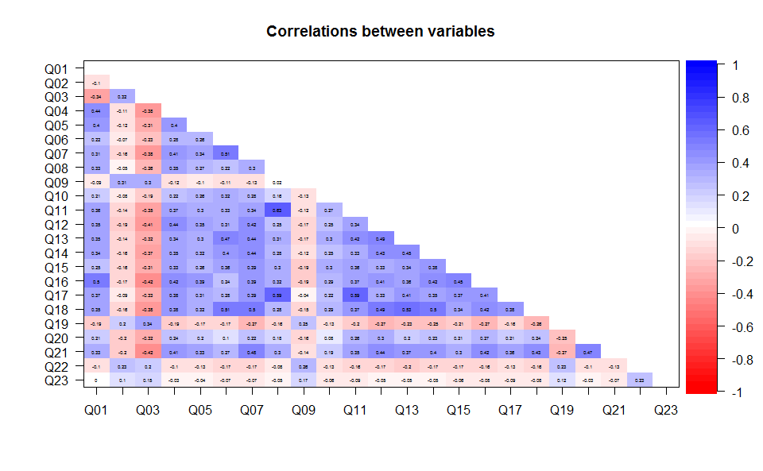

```r
corPlot(correlations,numbers=TRUE,upper=FALSE,diag=FALSE,main="Correlations between variables")
```

You will, however, notice that this is a rather subjective approach. The **Bartlett’s test** is a statistical test that can be used to test whether all the off-diagonal elements in the population correlation matrix are zero (i.e., whether the populaiton correlation matrix resembles an identify matrix). Thus, it tests whether the correlations are overall too small. If the matrix is an identify matrix, it means that all variables are independent. Thus, a significant test statistic (i.e., p < 0.05) indicates that there is some relationship between variables. The test can be implemented using the `cortest.bartlett()` function from the `psych` package:

```r
library(psych)
cortest.bartlett(raq_matrix, n = nrow(raq_data))
```

```
$chisq
[1] 19334.49

$p.value
[1] 0

$df
[1] 253
```

In our example, the p-value is less than 0.05, which is good news since it confirms that overall the correlation between variables is different from zero.

The other problem that might occur is that **the correlations are too high**. Actually, a certain degree of multicollinearity is not a problem in PCA. However, it is important to avoid extreme multicollinearity (i.e., variables are highly correlated) and singularity (i.e., variables are perfectly correlated). Multicollinearity causes problems, because it becomes difficult to determine the unique contribution of a variable (as was the case in linear regression analysis). Again, inspecting the entire correlation matrix when there are many variables will be a tedious task. .

```r
apply(abs(correlations) > 0.8, 1, sum, na.rm = TRUE)
```

```
Q01 Q02 Q03 Q04 Q05 Q06 Q07 Q08 Q09 Q10 Q11 Q12 Q13 Q14 Q15 Q16 Q17 Q18 Q19 Q20 Q21 Q22 Q23
  0   0   0   0   0   0   0   0   0   0   0   0   0   0   0   0   0   0   0   0   0   0   0
```

The results do not suggest any extreme or perfect correlations. Again, there is a more objective measure that could be applied. The **determinant** tells us whether the correlation matrix is singular (determinant = 0), or if all variables are completely unrelated (determinant = 1), or somewhere in between. As a rule of thumb, the determinant should be greater than 0.00001. The `det()` function can be used to compute the determinant:

```r
det(raq_matrix)
```

```
[1] 0.0005271037
```

```r
det(raq_matrix) > 0.00001
```

```
[1] TRUE
```

As you can see, the determinant is larger than the threshold, indicating that the overall correlation between variables is not too strong.

Finnally, you should test if the correlation pattern in the matrix is appropriate for factor analysis using the Kaiser-Meyer-Olkin (KMO) measure of sampling adequacy. This statistic is a measure of the proportion of variance among variables that might be common variance.

$$\begin{equation}
MSA_j=\frac{\sum_{k\ne j}^{}{r^2_{jk}}}{\sum_{k\ne j}^{}{r^2_{jk}}+\sum_{k\ne j}^{}{p^2_{jk}}}
(\#eq:MSA)
\end{equation}$$

where $r_{jk}$ is the correlation between two variabels of interest and $p_{jk}$ is their partial correlation. The partial correlation measures the degree of association between the two variables, when the effect of the remaining variables is controlled for. It can takes values between 0 (bad) and 1 (good), where a value of 0 indicates that the sum of partial correlations is large relative to the sum of correlations. If the remaining correlation between two variables remains high if you control for all the other variables, this provides an indication that the correlation is fairly concentrated and on a subset of the variables and factor analysis is likely to be inappropriate. In consrast, a value close to 1 means that the sum of the partial correlations is fairly is low, indicating a more compact pattern of correlations between a larger set of variables. Values should at least exceed 0.50, with the thresholds:

- <.50 = unacceptable
- >.50 = miserable
- >.60 = mediocre
- >.70 = middling
- >.80 = meritorious
- >.90 = marvelous

The KMO measure of sampling adequacy can be computed using the `KMO()` function from the `psych` package:

```r
KMO(raq_data)
```

```
Kaiser-Meyer-Olkin factor adequacy
Call: KMO(r = raq_data)
Overall MSA =  0.93
MSA for each item =
 Q01  Q02  Q03  Q04  Q05  Q06  Q07  Q08  Q09  Q10  Q11  Q12  Q13  Q14  Q15  Q16  Q17  Q18  Q19  Q20  Q21  Q22  Q23
0.93 0.87 0.95 0.96 0.96 0.89 0.94 0.87 0.83 0.95 0.91 0.95 0.95 0.97 0.94 0.93 0.93 0.95 0.94 0.89 0.93 0.88 0.77
```

You can see that the statistic is calculated for the entire matrix and for each variable individually. In our example, the values for all variables as well as the overall matrix is above 0.5, suggesting that factor analysis is appropriate.

### Deriving factors

After testing that the data can be used for PCA, we can move on to conducting PCA. Conducting PCA is fairly simple in R using the `pricipal()` function from the `psych` package. However, before the apply the function to our data, it is useful to reflect on the goals of PCA again. The goal is to explain the maximum amount of total variance in a correlation matrix by transforming the original variables into a smaller set of linear components (factors). So the first decision we have to make is how many factors we should extract. There are different methods that can be used to decide on the appropriate number of factors, including:

- **A priori determination**: Requires prior knowledge
- **Determination based on percentage of variance**: When cumulative percentage of variance extracted by the factors reaches a satisfactory level (e.g., factors extracted should account for at least 60% of the variance)
- **Eigenvalues**: Eigenvalues refer to the total variance that is explained by each factor. Factors with eigenvalues greater than 1.0 are retained (factors with a variance less than 1.0 are no better than a single variable)
- **Scree plot**: Is a plot of the eigenvalues against the number of factors in order of extraction. Assumption: the point at which the scree begins denotes the true number of factors.

Often, the decision is made based on a combination of different criteria.

By extracting as many factors as there are variables we can inspect their eigenvalues and make decisions about which factors to extract. Since we have 23 variables, we set the argument `nfactors` to 23.

```r
pc1 <- principal(raq_data, nfactors = 23, rotate = "none")
pc1
```

```
Principal Components Analysis
Call: principal(r = raq_data, nfactors = 23, rotate = "none")
Standardized loadings (pattern matrix) based upon correlation matrix
      PC1   PC2   PC3   PC4   PC5   PC6   PC7   PC8   PC9  PC10  PC11  PC12  PC13  PC14  PC15  PC16  PC17  PC18  PC19  PC20  PC21  PC22  PC23 h2
Q01  0.59  0.18 -0.22  0.12 -0.40 -0.11 -0.22 -0.08  0.01 -0.10  0.11 -0.12  0.30 -0.25  0.18  0.12 -0.05 -0.17  0.16 -0.01 -0.21  0.05  0.01  1
Q02 -0.30  0.55  0.15  0.01 -0.03 -0.38  0.19 -0.39  0.01 -0.12  0.30  0.27 -0.02  0.01 -0.24 -0.05 -0.08  0.00  0.01 -0.02 -0.02  0.03  0.02  1
Q03 -0.63  0.29  0.21 -0.07  0.02  0.00  0.01 -0.05  0.20  0.10  0.15  0.03  0.10  0.13  0.40 -0.06  0.43  0.08  0.09  0.05  0.01  0.00  0.05  1
Q04  0.63  0.14 -0.15  0.15 -0.20 -0.12 -0.06  0.11 -0.11 -0.01 -0.03  0.34 -0.32 -0.17  0.12  0.31  0.19  0.05 -0.21  0.04  0.09 -0.02  0.02  1
Q05  0.56  0.10 -0.07  0.14 -0.42 -0.17 -0.06  0.11  0.24  0.09 -0.30  0.16  0.12  0.48 -0.07 -0.08 -0.04  0.01 -0.04  0.00 -0.02  0.02  0.01  1
Q06  0.56  0.10  0.57 -0.05  0.17  0.01  0.00  0.05  0.00  0.00 -0.13  0.20  0.24 -0.03  0.08  0.20 -0.14  0.05  0.09 -0.07  0.04 -0.32 -0.11  1
Q07  0.69  0.04  0.25  0.10  0.17 -0.08  0.05  0.03 -0.08  0.13 -0.27  0.20  0.04 -0.22  0.00 -0.23  0.03 -0.15  0.20  0.16  0.14  0.24  0.09  1
Q08  0.55  0.40 -0.32 -0.42  0.15  0.10 -0.07 -0.04  0.01 -0.05 -0.09  0.03 -0.01  0.04 -0.04  0.03  0.10  0.07  0.12 -0.15  0.06  0.16 -0.36  1
Q09 -0.28  0.63 -0.01  0.10  0.17 -0.27 -0.01 -0.03  0.16  0.32 -0.22 -0.37 -0.17 -0.07  0.12  0.11 -0.19 -0.02 -0.08 -0.03  0.04 -0.01  0.03  1
Q10  0.44  0.03  0.36 -0.10 -0.34  0.22  0.44 -0.03  0.37 -0.22 -0.11 -0.21 -0.17 -0.15 -0.07  0.03  0.07 -0.01  0.00  0.04 -0.03  0.02 -0.04  1
Q11  0.65  0.25 -0.21 -0.40  0.13  0.18 -0.01  0.03  0.10 -0.14  0.00  0.03  0.02  0.03 -0.02  0.07 -0.05  0.07  0.07 -0.18  0.06  0.00  0.41  1
Q12  0.67 -0.05  0.05  0.25  0.04 -0.08 -0.14  0.08  0.01 -0.11  0.19 -0.07 -0.45  0.17  0.09 -0.10 -0.08  0.04  0.36  0.00 -0.04 -0.10 -0.02  1
Q13  0.67  0.08  0.28 -0.01  0.13  0.03 -0.21  0.05  0.08 -0.22  0.24 -0.08  0.01  0.12  0.14 -0.11 -0.06 -0.32 -0.30 -0.06  0.16  0.08 -0.05  1
Q14  0.66  0.02  0.20  0.14  0.08 -0.03 -0.10 -0.06 -0.14  0.16  0.08 -0.29  0.07  0.14 -0.37  0.25  0.34 -0.09  0.06  0.02  0.03 -0.01  0.05  1
Q15  0.59  0.01  0.12 -0.11 -0.07  0.29  0.32 -0.12 -0.27  0.41  0.15  0.09 -0.09  0.16  0.16  0.06 -0.12 -0.10 -0.04 -0.07 -0.19  0.10  0.00  1
Q16  0.68  0.01 -0.14  0.08 -0.32  0.00  0.12 -0.14 -0.19  0.15  0.16 -0.19  0.12 -0.08  0.06 -0.22 -0.03  0.22 -0.02 -0.04  0.35 -0.12 -0.01  1
Q17  0.64  0.33 -0.21 -0.34  0.10  0.05 -0.02  0.03 -0.04  0.02  0.01 -0.03 -0.01 -0.01 -0.05 -0.18  0.04 -0.04 -0.10  0.42 -0.15 -0.23 -0.01  1
Q18  0.70  0.03  0.30  0.13  0.15 -0.09 -0.10  0.06 -0.06 -0.12  0.05 -0.11  0.09  0.00  0.03 -0.01 -0.06  0.45 -0.15  0.08 -0.18  0.23  0.01  1
Q19 -0.43  0.39  0.10 -0.01 -0.15  0.07  0.05  0.68  0.02  0.16  0.29  0.04  0.06 -0.09 -0.16 -0.03 -0.06  0.01  0.05 -0.02  0.02  0.04 -0.02  1
Q20  0.44 -0.21 -0.40  0.30  0.33 -0.01  0.34  0.03  0.33  0.02  0.21  0.04  0.17  0.07  0.05  0.22 -0.09  0.00  0.04  0.18  0.10  0.06 -0.04  1
Q21  0.66 -0.06 -0.19  0.28  0.24 -0.15  0.18  0.10  0.12  0.08 -0.02  0.04  0.03 -0.15 -0.04 -0.27  0.20 -0.03 -0.11 -0.31 -0.20 -0.13 -0.01  1
Q22 -0.30  0.47 -0.12  0.38  0.07  0.12  0.31  0.12 -0.41 -0.39 -0.19 -0.10  0.08  0.15  0.09  0.01  0.04 -0.06  0.02  0.00  0.01 -0.01  0.01  1
Q23 -0.14  0.37 -0.02  0.51  0.02  0.62 -0.28 -0.22  0.18  0.08  0.00  0.13 -0.01 -0.07 -0.12 -0.06 -0.03  0.05 -0.03  0.01 -0.01 -0.02  0.00  1
          u2 com
Q01 -1.1e-15 6.0
Q02 -3.8e-15 6.1
Q03  6.7e-16 4.4
Q04 -1.1e-15 4.9
Q05 -6.7e-16 5.2
Q06 -4.4e-16 4.4
Q07 -4.4e-16 4.1
Q08 -1.3e-15 5.7
Q09 -1.3e-15 5.0
Q10  2.2e-16 7.7
Q11 -1.3e-15 4.1
Q12 -1.6e-15 3.8
```

[output cut: 11 more lines]

```

                       PC1  PC2  PC3  PC4  PC5  PC6  PC7  PC8  PC9 PC10 PC11 PC12 PC13 PC14 PC15 PC16 PC17 PC18 PC19 PC20 PC21 PC22 PC23
SS loadings           7.29 1.74 1.32 1.23 0.99 0.90 0.81 0.78 0.75 0.72 0.68 0.67 0.61 0.58 0.55 0.52 0.51 0.46 0.42 0.41 0.38 0.36 0.33
Proportion Var        0.32 0.08 0.06 0.05 0.04 0.04 0.04 0.03 0.03 0.03 0.03 0.03 0.03 0.03 0.02 0.02 0.02 0.02 0.02 0.02 0.02 0.02 0.01
Cumulative Var        0.32 0.39 0.45 0.50 0.55 0.59 0.62 0.65 0.69 0.72 0.75 0.78 0.80 0.83 0.85 0.88 0.90 0.92 0.94 0.95 0.97 0.99 1.00
Proportion Explained  0.32 0.08 0.06 0.05 0.04 0.04 0.04 0.03 0.03 0.03 0.03 0.03 0.03 0.03 0.02 0.02 0.02 0.02 0.02 0.02 0.02 0.02 0.01
Cumulative Proportion 0.32 0.39 0.45 0.50 0.55 0.59 0.62 0.65 0.69 0.72 0.75 0.78 0.80 0.83 0.85 0.88 0.90 0.92 0.94 0.95 0.97 0.99 1.00

Mean item complexity =  5
Test of the hypothesis that 23 components are sufficient.

The root mean square of the residuals (RMSR) is  0
 with the empirical chi square  0  with prob <  NA

Fit based upon off diagonal values = 1
```

The output is quite complex, but we will focus only on the `SS loadings` for now, which are the Eigenvalues (a.k.a. sum of squared loadings). One common rule is to retain factors with eigenvalues greater than 1.0. So based on this rule, we would extract four factors (i.e., the SS loadings for the fifth factor is < 1).

You can also plot the eigenvalues against the number of factors in order of extraction using a so-called **Scree plot**:

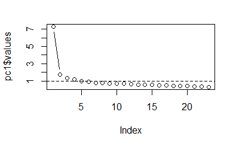

```r
plot(pc1$values, type="b")
abline(h=1, lty=2)
```

Now that we know how many components we want to extract, we can rerun the analysis, specifying that number:

```r
pc2 <- principal(raq_data, nfactors = 4, rotate = "none")
pc2
```

```
Principal Components Analysis
Call: principal(r = raq_data, nfactors = 4, rotate = "none")
Standardized loadings (pattern matrix) based upon correlation matrix
      PC1   PC2   PC3   PC4   h2   u2 com
Q01  0.59  0.18 -0.22  0.12 0.43 0.57 1.6
Q02 -0.30  0.55  0.15  0.01 0.41 0.59 1.7
Q03 -0.63  0.29  0.21 -0.07 0.53 0.47 1.7
Q04  0.63  0.14 -0.15  0.15 0.47 0.53 1.3
Q05  0.56  0.10 -0.07  0.14 0.34 0.66 1.2
Q06  0.56  0.10  0.57 -0.05 0.65 0.35 2.1
Q07  0.69  0.04  0.25  0.10 0.55 0.45 1.3
Q08  0.55  0.40 -0.32 -0.42 0.74 0.26 3.5
Q09 -0.28  0.63 -0.01  0.10 0.48 0.52 1.5
Q10  0.44  0.03  0.36 -0.10 0.33 0.67 2.1
Q11  0.65  0.25 -0.21 -0.40 0.69 0.31 2.2
Q12  0.67 -0.05  0.05  0.25 0.51 0.49 1.3
Q13  0.67  0.08  0.28 -0.01 0.54 0.46 1.4
Q14  0.66  0.02  0.20  0.14 0.49 0.51 1.3
Q15  0.59  0.01  0.12 -0.11 0.38 0.62 1.2
Q16  0.68  0.01 -0.14  0.08 0.49 0.51 1.1
Q17  0.64  0.33 -0.21 -0.34 0.68 0.32 2.4
Q18  0.70  0.03  0.30  0.13 0.60 0.40 1.4
Q19 -0.43  0.39  0.10 -0.01 0.34 0.66 2.1
Q20  0.44 -0.21 -0.40  0.30 0.48 0.52 3.2
Q21  0.66 -0.06 -0.19  0.28 0.55 0.45 1.6
Q22 -0.30  0.47 -0.12  0.38 0.46 0.54 2.8
Q23 -0.14  0.37 -0.02  0.51 0.41 0.59 2.0

                       PC1  PC2  PC3  PC4
SS loadings           7.29 1.74 1.32 1.23
Proportion Var        0.32 0.08 0.06 0.05
Cumulative Var        0.32 0.39 0.45 0.50
Proportion Explained  0.63 0.15 0.11 0.11
Cumulative Proportion 0.63 0.78 0.89 1.00

Mean item complexity =  1.8
Test of the hypothesis that 4 components are sufficient.

The root mean square of the residuals (RMSR) is  0.06
 with the empirical chi square  4006.15  with prob <  0

Fit based upon off diagonal values = 0.96
```

Now that the output is less complex, we can inspect the remaining statistics. The first part of the output is the **factor matrix**, which contains the factor loadings of all the variables on the four extracted factors (i.e., PC1, PC2, PC3, PC4). As we have said before, the **factor loadings** are the correlations between the variables and the factors. The factor matrix also contains the columsn “h2” and “u2”. “h2” refers to the **communality**, which is the proportion of variance a variable shares with all the other variables being considered. This is also the proportion of variance explained by the common factors. In contrast, “u2” refers to the unique variance, which is the proportion of the variance that is unique to a particular variable. In PCA, we are primarily interested in the common variance. When the communality is very low (say <.30), a variable is “quite unique” and should be removed, as it is definitely measuring “something else”. In our example, all comunalities (i.e., h2) are above 0.3 so that we retain all variables.

Note that there is a difference between PCA and common factor analysis. PCA focuses on the variance and aims to reproduce the total variable variance. This means that the components reflect both common and unique variance of the variables. Factor analysis, in contrast, focuses on the correlation and aims to reproduce the correlations among variables. Here, the factors only represent the common variance that variable share and do not include the unique variance. In other words, while factor analysis focuses on explaining the off-diagonal terms in the correlation matrix (i.e., shared co-variance), PCA focuses on explaining the diagonal terms (i.e., the variances). However, although PCA aims to reproduce the on-diagonal terms in the correlation matrix, it also tends to fit the off-diagonal correlations quite well. Hence, the results are often comparable. See also [here](https://en.wikipedia.org/wiki/Principal_component_analysis#Relation_between_PCA_and_factor_analysis).

You should also take a closer look at the residuals in order to check whether you have extracted the correct number of factors. The difference between the reproduced and the actual correlation matrices are the residuals. We can extract the residuals from our model using the `factor.residuals()` function from the `psych` package. It takes the original correlation matrix and the factor loadings as arguments:

```r
residuals <- factor.residuals(raq_matrix, pc2$loadings)
round(residuals,3)
```

```
       Q01    Q02    Q03    Q04    Q05    Q06    Q07    Q08    Q09    Q10    Q11    Q12    Q13    Q14    Q15    Q16    Q17    Q18    Q19    Q20
Q01  0.565  0.013  0.035 -0.011  0.027 -0.001 -0.061 -0.081 -0.050  0.042 -0.066 -0.057  0.008 -0.024 -0.065  0.059 -0.069 -0.020  0.015 -0.128
Q02  0.013  0.586 -0.062  0.022  0.003 -0.041 -0.011 -0.052 -0.115 -0.023 -0.046  0.024 -0.021 -0.009 -0.007  0.050 -0.039 -0.015 -0.153  0.099
Q03  0.035 -0.062  0.470  0.019  0.035 -0.027 -0.009  0.011 -0.052 -0.013  0.006  0.030  0.024  0.002  0.025  0.039  0.003  0.001 -0.061  0.115
Q04 -0.011  0.022  0.019  0.531  0.002  0.000 -0.010 -0.041 -0.051  0.003 -0.051 -0.006 -0.051 -0.060 -0.009 -0.050 -0.052 -0.042  0.045 -0.110
Q05  0.027  0.003  0.035  0.002  0.657 -0.016 -0.041 -0.044 -0.016  0.053 -0.050 -0.050 -0.058 -0.055 -0.045 -0.005 -0.049 -0.066  0.041 -0.092
Q06 -0.001 -0.041 -0.027  0.000 -0.016  0.346 -0.014  0.040 -0.005 -0.139  0.038 -0.076 -0.078 -0.075 -0.047 -0.056 -0.008 -0.048 -0.020  0.122
Q07 -0.061 -0.011 -0.009 -0.010 -0.041 -0.014  0.455  0.030  0.033 -0.098 -0.018 -0.072 -0.091 -0.074 -0.033 -0.051  0.025 -0.069 -0.015  0.002
Q08 -0.081 -0.052  0.011 -0.041 -0.044  0.040  0.030  0.261 -0.039 -0.021 -0.061  0.024  0.001  0.032 -0.039 -0.068 -0.105  0.030 -0.056  0.011
Q09 -0.050 -0.115 -0.052 -0.051 -0.016 -0.005  0.033 -0.039  0.516 -0.018 -0.045  0.027 -0.021  0.038 -0.012 -0.014 -0.027  0.018 -0.114  0.060
Q10  0.042 -0.023 -0.013  0.003  0.053 -0.139 -0.098 -0.021 -0.018  0.665  0.012 -0.038 -0.096 -0.091 -0.018  0.052 -0.033 -0.110  0.010  0.078
Q11 -0.066 -0.046  0.006 -0.051 -0.050  0.038 -0.018 -0.061 -0.045  0.012  0.310  0.020  0.020 -0.013 -0.045 -0.075 -0.094  0.020 -0.002  0.056
Q12 -0.057  0.024  0.030 -0.006 -0.050 -0.076 -0.072  0.024  0.027 -0.038  0.020  0.487  0.030 -0.048 -0.042 -0.058  0.014 -0.020  0.036 -0.056
Q13  0.008 -0.021  0.024 -0.051 -0.058 -0.078 -0.091  0.001 -0.021 -0.096  0.020  0.030  0.464 -0.047 -0.091 -0.061  0.006 -0.023  0.004  0.041
Q14 -0.024 -0.009  0.002 -0.060 -0.055 -0.075 -0.074  0.032  0.038 -0.091 -0.013 -0.048 -0.047  0.512 -0.017 -0.011  0.012 -0.038  0.000 -0.015
Q15 -0.065 -0.007  0.025 -0.009 -0.045 -0.047 -0.033 -0.039 -0.012 -0.018 -0.045 -0.042 -0.091 -0.017  0.622  0.077 -0.025 -0.094  0.027  0.031
Q16  0.059  0.050  0.039 -0.050 -0.005 -0.056 -0.051 -0.068 -0.014  0.052 -0.075 -0.058 -0.061 -0.011  0.077  0.513 -0.034 -0.024  0.032 -0.108
Q17 -0.069 -0.039  0.003 -0.052 -0.049 -0.008  0.025 -0.105 -0.027 -0.033 -0.094  0.014  0.006  0.012 -0.025 -0.034  0.317  0.019 -0.001  0.009
Q18 -0.020 -0.015  0.001 -0.042 -0.066 -0.048 -0.069  0.030  0.018 -0.110  0.020 -0.020 -0.023 -0.038 -0.094 -0.024  0.019  0.403  0.003  0.020
Q19  0.015 -0.153 -0.061  0.045  0.041 -0.020 -0.015 -0.056 -0.114  0.010 -0.002  0.036  0.004  0.000  0.027  0.032 -0.001  0.003  0.657  0.060
Q20 -0.128  0.099  0.115 -0.110 -0.092  0.122  0.002  0.011  0.060  0.078  0.056 -0.056  0.041 -0.015  0.031 -0.108  0.009  0.020  0.060  0.516
Q21 -0.120  0.049  0.071 -0.070 -0.078  0.029  0.053  0.014  0.055  0.005  0.005 -0.062 -0.010 -0.032 -0.036 -0.074  0.016 -0.009  0.049  0.010
Q22 -0.079 -0.102 -0.071 -0.049 -0.072  0.043  0.010  0.020 -0.161  0.066  0.047 -0.031  0.007 -0.011  0.062 -0.004  0.019  0.023 -0.060 -0.032
Q23 -0.049 -0.147 -0.008 -0.076 -0.070  0.013 -0.033  0.086 -0.152  0.048  0.116 -0.057  0.026 -0.027  0.079 -0.032  0.049 -0.049 -0.073 -0.056
       Q21    Q22    Q23
Q01 -0.120 -0.079 -0.049
Q02  0.049 -0.102 -0.147
Q03  0.071 -0.071 -0.008
Q04 -0.070 -0.049 -0.076
Q05 -0.078 -0.072 -0.070
Q06  0.029  0.043  0.013
Q07  0.053  0.010 -0.033
Q08  0.014  0.020  0.086
Q09  0.055 -0.161 -0.152
Q10  0.005  0.066  0.048
Q11  0.005  0.047  0.116
Q12 -0.062 -0.031 -0.057
Q13 -0.010  0.007  0.026
Q14 -0.032 -0.011 -0.027
Q15 -0.036  0.062  0.079
Q16 -0.074 -0.004 -0.032
Q17  0.016  0.019  0.049
Q18 -0.009  0.023 -0.049
Q19  0.049 -0.060 -0.073
Q20  0.010 -0.032 -0.056
Q21  0.450 -0.033 -0.100
Q22 -0.033  0.536 -0.177
Q23 -0.100 -0.177  0.588
```

Note that the diagonal elements in the residual matrix correspond to the unique variance in each variable that cannot be explained by the factors (i.e., “u2” in the output above). For example, the proportion of unique variance for question 1 is 0.57, which is reflected in the first cell in the residual matrix. The off-diagonal elements represent the difference between the actual correlations and the correlation based on the reproduced correlation matrix for all variable pairs. To see this, the reproduced correlation matrix could be generated by using the `factor.model()` function:

```r
reproduced_matrix <- factor.model(pc2$loadings)
round(reproduced_matrix,3)
```

```
       Q01    Q02    Q03    Q04    Q05    Q06    Q07    Q08    Q09    Q10    Q11    Q12    Q13    Q14    Q15    Q16    Q17    Q18    Q19    Q20
Q01  0.435 -0.112 -0.372  0.447  0.376  0.218  0.366  0.412 -0.042  0.172  0.423  0.402  0.347  0.362  0.311  0.440  0.439  0.368 -0.204  0.342
Q02 -0.112  0.414  0.380 -0.134 -0.122 -0.033 -0.148  0.002  0.430 -0.061 -0.097 -0.219 -0.122 -0.155 -0.158 -0.217 -0.048 -0.149  0.357 -0.301
Q03 -0.372  0.380  0.530 -0.399 -0.345 -0.200 -0.373 -0.270  0.352 -0.181 -0.357 -0.440 -0.342 -0.373 -0.337 -0.458 -0.331 -0.376  0.403 -0.440
Q04  0.447 -0.134 -0.399  0.469  0.399  0.278  0.419  0.390 -0.073  0.212  0.419  0.448  0.395  0.411  0.343  0.466  0.434  0.424 -0.231  0.353
Q05  0.376 -0.122 -0.345  0.399  0.343  0.273  0.380  0.312 -0.080  0.205  0.348  0.397  0.360  0.370  0.306  0.400  0.359  0.388 -0.207  0.292
Q06  0.218 -0.033 -0.200  0.278  0.273  0.654  0.528  0.183 -0.108  0.461  0.290  0.388  0.545  0.477  0.406  0.300  0.290  0.562 -0.147 -0.021
Q07  0.366 -0.148 -0.373  0.419  0.380  0.528  0.545  0.267 -0.161  0.382  0.363  0.495  0.533  0.514  0.425  0.439  0.365  0.570 -0.254  0.219
Q08  0.412  0.002 -0.270  0.390  0.312  0.183  0.267  0.739  0.055  0.180  0.691  0.228  0.313  0.249  0.339  0.390  0.695  0.250 -0.104  0.164
Q09 -0.042  0.430  0.352 -0.073 -0.080 -0.108 -0.161  0.055  0.484 -0.116 -0.071 -0.195 -0.147 -0.159 -0.174 -0.175 -0.009 -0.168  0.363 -0.218
Q10  0.172 -0.061 -0.181  0.212  0.205  0.461  0.382  0.180 -0.116  0.335  0.259  0.283  0.398  0.345  0.314  0.239  0.252  0.403 -0.137  0.006
Q11  0.423 -0.097 -0.357  0.419  0.348  0.290  0.363  0.691 -0.071  0.259  0.690  0.315  0.403  0.338  0.410  0.444  0.681  0.353 -0.198  0.200
Q12  0.402 -0.219 -0.440  0.448  0.397  0.388  0.495  0.228 -0.195  0.283  0.315  0.513  0.459  0.481  0.374  0.466  0.319  0.513 -0.302  0.354
Q13  0.347 -0.122 -0.342  0.395  0.360  0.545  0.533  0.313 -0.147  0.398  0.403  0.459  0.536  0.497  0.433  0.419  0.402  0.556 -0.231  0.163
Q14  0.362 -0.155 -0.373  0.411  0.370  0.477  0.514  0.249 -0.159  0.345  0.338  0.481  0.497  0.488  0.397  0.429  0.342  0.537 -0.254  0.241
Q15  0.311 -0.158 -0.337  0.343  0.306  0.406  0.425  0.339 -0.174  0.314  0.410  0.374  0.433  0.397  0.378  0.378  0.399  0.437 -0.236  0.175
Q16  0.440 -0.217 -0.458  0.466  0.400  0.300  0.439  0.390 -0.175  0.239  0.444  0.466  0.419  0.429  0.378  0.487  0.443  0.446 -0.299  0.373
Q17  0.439 -0.048 -0.331  0.434  0.359  0.290  0.365  0.695 -0.009  0.252  0.681  0.319  0.402  0.342  0.399  0.443  0.683  0.357 -0.162  0.196
Q18  0.368 -0.149 -0.376  0.424  0.388  0.562  0.570  0.250 -0.168  0.403  0.353  0.513  0.556  0.537  0.437  0.446  0.357  0.597 -0.259  0.215
Q19 -0.204  0.357  0.403 -0.231 -0.207 -0.147 -0.254 -0.104  0.363 -0.137 -0.198 -0.302 -0.231 -0.254 -0.236 -0.299 -0.162 -0.259  0.343 -0.308
Q20  0.342 -0.301 -0.440  0.353  0.292 -0.021  0.219  0.164 -0.218  0.006  0.200  0.354  0.163  0.241  0.175  0.373  0.196  0.215 -0.308  0.484
Q21  0.449 -0.254 -0.488  0.480  0.412  0.244  0.430  0.282 -0.191  0.188  0.342  0.503  0.384  0.431  0.336  0.494  0.347  0.439 -0.324  0.457
Q22 -0.025  0.333  0.275 -0.050 -0.060 -0.209 -0.179 -0.099  0.417 -0.197 -0.209 -0.136 -0.203 -0.159 -0.230 -0.152 -0.145 -0.183  0.294 -0.068
Q23  0.045  0.246  0.158  0.042  0.028 -0.082 -0.037 -0.136  0.323 -0.110 -0.202  0.011 -0.079 -0.022 -0.141 -0.049 -0.140 -0.032  0.196  0.021
       Q21    Q22    Q23
Q01  0.449 -0.025  0.045
Q02 -0.254  0.333  0.246
Q03 -0.488  0.275  0.158
Q04  0.480 -0.050  0.042
Q05  0.412 -0.060  0.028
Q06  0.244 -0.209 -0.082
Q07  0.430 -0.179 -0.037
Q08  0.282 -0.099 -0.136
Q09 -0.191  0.417  0.323
Q10  0.188 -0.197 -0.110
Q11  0.342 -0.209 -0.202
Q12  0.503 -0.136  0.011
Q13  0.384 -0.203 -0.079
Q14  0.431 -0.159 -0.022
Q15  0.336 -0.230 -0.141
Q16  0.494 -0.152 -0.049
Q17  0.347 -0.145 -0.140
Q18  0.439 -0.183 -0.032
Q19 -0.324  0.294  0.196
Q20  0.457 -0.068  0.021
Q21  0.550 -0.096  0.032
Q22 -0.096  0.464  0.408
Q23  0.032  0.408  0.412
```

You can see that the reproduced correlation between the first and second variable is -0.112. From the correlation table from the beginning we know, however, that the observed correlation was -0.099. Hence, the difference between the observed and reproduced correlation is: (-0.099)-(-0.112) = 0.013, which correspondes to the residual of this variable pair in the residual matrix. Note that the diagonal elements in the reproduced matrix correspond to the communalities in the model summary above (i.e., “h2”).

A measure of fit can now be computed based on the size of the residuals. In the worst case, the residuals would be as large as the correlations in the original matrix, which would be the case if we extracted no factors at all. A measure of fit could therefore be the sum of the squared residuals divided by the sum of the squared correlations. We square the residuals to account for positive and negative deviaitons. **Values >0.90 are considered indicators of good fit.** From the output above, you can see that: “Fit based upon off diagonal values = 0.96”. Thus, we conclude that the model fit is sufficient.

You could also manually compute this statistic by summing over the squared residuals and correlations, take their ratio and subtract it from one (note that we use the `upper.tri()` function to use the upper triangle of the matrix only; this has the effect of discarding the diagonal elements and the elements below the diagonal).

```r
ssr <- (sum(residuals[upper.tri((residuals))]^2)) #sum of squared residuals
ssc <- (sum(raq_matrix[upper.tri((raq_matrix))]^2)) #sum of squared correlations
1-(ssr/ssc) #model fit
```

```
[1] 0.9645252
```

In a next step, we check the size of the residuals. **If fewer residuals than 50% have absolute values greater than 0.05 the model is a good fit.** This can be tested using the following code. We first convert the residuals to a matrix and select the upper triagular again to avoid duplicates. Finally, we count all occurences where the absolute value is larger than 0.05 and divide it by the number of total observations to get the proportion.

```r
residuals <- as.matrix(residuals[upper.tri((residuals))])
large_res <- abs(residuals) > 0.05
sum(large_res)
```

```
[1] 91
```

```r
sum(large_res)/nrow(residuals)
```

```
[1] 0.3596838
```

In our example, we can confirm that the proportion of residuals > 0.05 is less than 50%.

Another way to evaluate the residuals is by looking at their mean value (rather, we square the residuals first to account for positive and negative values, compute the mean and then take the square root).

```r
sqrt(mean(residuals^2))
```

```
[1] 0.05549286
```

This means that our mean residual is 0.055 and this value should be as low as possible.

Finally, we need to validate if the residuals are approximately normally distributed, which we do by using a histogram, a Q-Q plot and the Shapiro test.

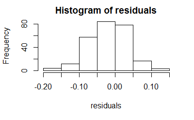

```r
hist(residuals)
```

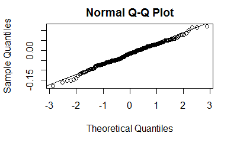

```r
qqnorm(residuals)
qqline(residuals)
```

```r
shapiro.test(residuals)
```

```
    Shapiro-Wilk normality test

data:  residuals
W = 0.99436, p-value = 0.4691
```

All of the tests suggest that the distribution of the residuals is approximately normal.

### Factor interpretation

To aid interpretation, it is possible to maximize the loading of a variable on one factor while minimizing its loading on all other factors. This is known as factor rotation. There are two types of factor rotation:

- orthogonal (assumes that factors are uncorrelated)
- oblique (assumes that factors are intercorrelated)

To carry out a orthogonal rotation, we change the rotate option in the `principal()` function from “none” to “varimax” (we could also exclude it altogether because varimax is the default if the option is not specified):

```r
pc3 <- principal(raq_data, nfactors = 4, rotate = "varimax")
pc3
```

```
Principal Components Analysis
Call: principal(r = raq_data, nfactors = 4, rotate = "varimax")
Standardized loadings (pattern matrix) based upon correlation matrix
      RC3   RC1   RC4   RC2   h2   u2 com
Q01  0.24  0.50  0.36  0.06 0.43 0.57 2.4
Q02 -0.01 -0.34  0.07  0.54 0.41 0.59 1.7
Q03 -0.20 -0.57 -0.18  0.37 0.53 0.47 2.3
Q04  0.32  0.52  0.31  0.04 0.47 0.53 2.4
Q05  0.32  0.43  0.24  0.01 0.34 0.66 2.5
Q06  0.80 -0.01  0.10 -0.07 0.65 0.35 1.0
Q07  0.64  0.33  0.16 -0.08 0.55 0.45 1.7
Q08  0.13  0.17  0.83  0.01 0.74 0.26 1.1
Q09 -0.09 -0.20  0.12  0.65 0.48 0.52 1.3
Q10  0.55  0.00  0.13 -0.12 0.33 0.67 1.2
Q11  0.26  0.21  0.75 -0.14 0.69 0.31 1.5
Q12  0.47  0.52  0.09 -0.08 0.51 0.49 2.1
Q13  0.65  0.23  0.23 -0.10 0.54 0.46 1.6
Q14  0.58  0.36  0.14 -0.07 0.49 0.51 1.8
Q15  0.46  0.22  0.29 -0.19 0.38 0.62 2.6
Q16  0.33  0.51  0.31 -0.12 0.49 0.51 2.6
Q17  0.27  0.22  0.75 -0.04 0.68 0.32 1.5
Q18  0.68  0.33  0.13 -0.08 0.60 0.40 1.5
Q19 -0.15 -0.37 -0.03  0.43 0.34 0.66 2.2
Q20 -0.04  0.68  0.07 -0.14 0.48 0.52 1.1
Q21  0.29  0.66  0.16 -0.07 0.55 0.45 1.5
Q22 -0.19  0.03 -0.10  0.65 0.46 0.54 1.2
Q23 -0.02  0.17 -0.20  0.59 0.41 0.59 1.4

                       RC3  RC1  RC4  RC2
SS loadings           3.73 3.34 2.55 1.95
Proportion Var        0.16 0.15 0.11 0.08
Cumulative Var        0.16 0.31 0.42 0.50
Proportion Explained  0.32 0.29 0.22 0.17
Cumulative Proportion 0.32 0.61 0.83 1.00

Mean item complexity =  1.8
Test of the hypothesis that 4 components are sufficient.

The root mean square of the residuals (RMSR) is  0.06
 with the empirical chi square  4006.15  with prob <  0

Fit based upon off diagonal values = 0.96
```

Interpreting the factor loading matrix is a little complex, so we can make it easier by using the `print.psych()` function, which we can use to exclude loading below a cutoff from the display and order the variables by their loading within each factor. In the following, we will only display loadings that exceed the value 0.3.

```r
print.psych(pc3, cut = 0.3, sort = TRUE)
```

```
Principal Components Analysis
Call: principal(r = raq_data, nfactors = 4, rotate = "varimax")
Standardized loadings (pattern matrix) based upon correlation matrix
    item   RC3   RC1   RC4   RC2   h2   u2 com
Q06    6  0.80                   0.65 0.35 1.0
Q18   18  0.68  0.33             0.60 0.40 1.5
Q13   13  0.65                   0.54 0.46 1.6
Q07    7  0.64  0.33             0.55 0.45 1.7
Q14   14  0.58  0.36             0.49 0.51 1.8
Q10   10  0.55                   0.33 0.67 1.2
Q15   15  0.46                   0.38 0.62 2.6
Q20   20        0.68             0.48 0.52 1.1
Q21   21        0.66             0.55 0.45 1.5
Q03    3       -0.57        0.37 0.53 0.47 2.3
Q12   12  0.47  0.52             0.51 0.49 2.1
Q04    4  0.32  0.52  0.31       0.47 0.53 2.4
Q16   16  0.33  0.51  0.31       0.49 0.51 2.6
Q01    1        0.50  0.36       0.43 0.57 2.4
Q05    5  0.32  0.43             0.34 0.66 2.5
Q08    8              0.83       0.74 0.26 1.1
Q17   17              0.75       0.68 0.32 1.5
Q11   11              0.75       0.69 0.31 1.5
Q09    9                    0.65 0.48 0.52 1.3
Q22   22                    0.65 0.46 0.54 1.2
Q23   23                    0.59 0.41 0.59 1.4
Q02    2       -0.34        0.54 0.41 0.59 1.7
Q19   19       -0.37        0.43 0.34 0.66 2.2

                       RC3  RC1  RC4  RC2
SS loadings           3.73 3.34 2.55 1.95
Proportion Var        0.16 0.15 0.11 0.08
Cumulative Var        0.16 0.31 0.42 0.50
Proportion Explained  0.32 0.29 0.22 0.17
Cumulative Proportion 0.32 0.61 0.83 1.00

Mean item complexity =  1.8
Test of the hypothesis that 4 components are sufficient.

The root mean square of the residuals (RMSR) is  0.06
 with the empirical chi square  4006.15  with prob <  0

Fit based upon off diagonal values = 0.96
```

After obtaining the rotated matrix, variables with high loading are used for interpreting (=naming) the factor. Note that factor loading can be positive or negative (depends on scaling of the variable), thus take care when interpreting! Look for simple structure: each variable (hopefully) loads high on 1 factor and low on other factors.

As an example, we could name our factors as follows:

- **Factor 1:** fear of computers
- **Factor 2:** fear of statistics
- **Factor 3:** fear of maths
- **Factor 4:** Peer evaluation

The previous type of rotation (i.e., “varimax”) assumed that the the factors are independent. Oblique rotation is another type of rotation that can handle correlation between the factors. The command for an oblique rotation is very similar to that for an orthogonal rotation – we just change the rotate option from “varimax” to “oblimin”.

```r
pc4 <- principal(raq_data, nfactors = 4, rotate = "oblimin", scores = TRUE)
print.psych(pc4, cut = 0.3, sort = TRUE)
```

```
Principal Components Analysis
Call: principal(r = raq_data, nfactors = 4, rotate = "oblimin", scores = TRUE)
Standardized loadings (pattern matrix) based upon correlation matrix
    item   TC1   TC4   TC3   TC2   h2   u2 com
Q06    6  0.87                   0.65 0.35 1.1
Q18   18  0.70                   0.60 0.40 1.1
Q07    7  0.64                   0.55 0.45 1.2
Q13   13  0.64                   0.54 0.46 1.1
Q10   10  0.57                   0.33 0.67 1.2
Q14   14  0.57                   0.49 0.51 1.3
Q12   12  0.45        0.43       0.51 0.49 2.0
Q15   15  0.40                   0.38 0.62 1.9
Q08    8        0.90             0.74 0.26 1.0
Q11   11        0.78             0.69 0.31 1.0
Q17   17        0.78             0.68 0.32 1.0
Q20   20              0.71       0.48 0.52 1.1
Q21   21              0.60       0.55 0.45 1.3
Q03    3             -0.51       0.53 0.47 1.8
Q04    4              0.41       0.47 0.53 2.6
Q16   16              0.41       0.49 0.51 2.4
Q01    1        0.33  0.40       0.43 0.57 2.4
Q05    5              0.34       0.34 0.66 2.7
Q22   22                    0.65 0.46 0.54 1.2
Q09    9                    0.63 0.48 0.52 1.4
Q23   23                    0.61 0.41 0.59 1.6
Q02    2             -0.36  0.51 0.41 0.59 1.9
Q19   19             -0.35  0.38 0.34 0.66 2.1

                       TC1  TC4  TC3  TC2
SS loadings           3.90 2.88 2.94 1.85
Proportion Var        0.17 0.13 0.13 0.08
Cumulative Var        0.17 0.29 0.42 0.50
Proportion Explained  0.34 0.25 0.25 0.16
Cumulative Proportion 0.34 0.59 0.84 1.00

 With component correlations of
      TC1   TC4   TC3   TC2
TC1  1.00  0.44  0.36 -0.18
TC4  0.44  1.00  0.31 -0.10
TC3  0.36  0.31  1.00 -0.17
TC2 -0.18 -0.10 -0.17  1.00

Mean item complexity =  1.6
Test of the hypothesis that 4 components are sufficient.

The root mean square of the residuals (RMSR) is  0.06
 with the empirical chi square  4006.15  with prob <  0

Fit based upon off diagonal values = 0.96
```

The component correlations indicate that the factors might indeed be correlated, so oblique rotation might actually be more appropriate in this case.

### Creating new variables

```r
head(pc4$scores)
```

```
             TC1        TC4         TC3        TC2
[1,]  0.37296709  1.8808424  0.95979596  0.3910711
[2,]  0.63334164  0.2374679  0.29090777 -0.3504080
[3,]  0.39712768 -0.1056263 -0.09333769  0.9249353
[4,] -0.78741595  0.2956628 -0.77703307  0.2605666
[5,]  0.04425942  0.6815179  0.59786611 -0.6912687
[6,] -1.70018648  0.2091685  0.02784164  0.6653081
```

We can also use the `cbind()` function to add the computed factor scores to the existing data set:

```r
raq_data <- cbind(raq_data, pc4$scores)
```

This way, it is easier to use the new variables in subsequent analysis (e.g., t-tests, regression, ANOVA, cluster analysis).

## Reliability analysis

When you are using multi-item scales to measure a latent construct (e.g., the output from the PCA above), it is useful to check the reliability of your scale. Reliability means that our items should consistently reflect the construct that they are intended to measure. In other words, individual items should produce results consistent with the overall scale. This means that for a scale to be reliable, the score of a person on one half of the items should be similar to the score derived based on the other half of the items (split-half reliability). The problem is that there are several ways in which data can be split. A measure that reflects this underlying intuition is **Cronbach’s alpha**, which is approximately equal to the average of all possible split-half reliabilities. It is computed as follows:

$$\begin{equation}
\alpha=\frac{N^2\overline{Cov}}{\sum{s^2_{item}}+\sum{Cov_{item}}}
(\#eq:calpha)
\end{equation}$$

The share of the items common variance (inter-correlation) in the total variance is supposed to be as high as possible across all items. The thresholds are as follows:

- >0.7 reasonable for practical application/explorative research
- >0.8 necessary for fundamental research
- >0.9 desirable for applied research

To see if the subscales that were derived from the previous PCA exhibit a sufficient degree of reliability, we first create subsets of our data set that contain the respective items for each of the factors (we use the results from the oblimin rotation here):

```r
computer_fear <- raq_data[,c(6,7,10,13,14,15,18)]
statistics_fear <- raq_data[,c(1,3,4,5,12,16,20,21)]
math_fear <- raq_data[,c(8,11,17)]
peer_evaluation <- raq_data[,c(2,9,19,22,23)]
```

Now we can use the `alpha()` function from the `psych` package to test the reliability. Note that the `keys` argument may be used to indicate reverse coded items. In the example below, the second item of the “statistics_fear” factor is reverse coded as indicated by the `-1`, meaning that it is phrased in a “positive” way, while the remaining items belonging to this factor are phrased in a “negative” way. This is often done to check if respondents are giving consistent answers.

```r
psych::alpha(computer_fear)
```

```
Reliability analysis
Call: psych::alpha(x = computer_fear)

  raw_alpha std.alpha G6(smc) average_r S/N    ase mean   sd
      0.82      0.82    0.81       0.4 4.6 0.0052  3.4 0.71

 lower alpha upper     95% confidence boundaries
0.81 0.82 0.83

 Reliability if an item is dropped:
    raw_alpha std.alpha G6(smc) average_r S/N alpha se
Q06      0.79      0.79    0.77      0.38 3.7   0.0063
Q07      0.79      0.79    0.77      0.38 3.7   0.0063
Q10      0.82      0.82    0.80      0.44 4.7   0.0053
Q13      0.79      0.79    0.77      0.39 3.8   0.0062
Q14      0.80      0.80    0.77      0.39 3.9   0.0060
Q15      0.81      0.81    0.79      0.41 4.2   0.0056
Q18      0.79      0.78    0.76      0.38 3.6   0.0064

 Item statistics
       n raw.r std.r r.cor r.drop mean   sd
Q06 2571  0.75  0.74  0.68   0.62  3.8 1.12
Q07 2571  0.75  0.73  0.68   0.62  3.1 1.10
Q10 2571  0.54  0.57  0.44   0.40  3.7 0.88
Q13 2571  0.72  0.73  0.67   0.61  3.6 0.95
Q14 2571  0.70  0.70  0.64   0.58  3.1 1.00
Q15 2571  0.64  0.64  0.54   0.49  3.2 1.01
Q18 2571  0.76  0.76  0.72   0.65  3.4 1.05

Non missing response frequency for each item
       1    2    3    4    5 miss
Q06 0.06 0.10 0.13 0.44 0.27    0
Q07 0.09 0.24 0.26 0.34 0.07    0
Q10 0.02 0.10 0.18 0.57 0.14    0
Q13 0.03 0.12 0.25 0.48 0.12    0
Q14 0.07 0.18 0.38 0.31 0.06    0
Q15 0.06 0.18 0.30 0.39 0.07    0
Q18 0.06 0.12 0.31 0.37 0.14    0
```

```r
psych::alpha(statistics_fear, keys=c(1,-1,1,1,1,1,1,1))
```

```
Reliability analysis
Call: psych::alpha(x = statistics_fear, keys = c(1, -1, 1, 1, 1, 1,
    1, 1))

  raw_alpha std.alpha G6(smc) average_r S/N    ase mean   sd
      0.82      0.82    0.81      0.37 4.7 0.0053    3 0.64

 lower alpha upper     95% confidence boundaries
0.81 0.82 0.83

 Reliability if an item is dropped:
     raw_alpha std.alpha G6(smc) average_r S/N alpha se
Q01       0.80      0.80    0.79      0.37 4.1   0.0060
Q03-      0.80      0.80    0.79      0.37 4.1   0.0061
Q04       0.80      0.80    0.78      0.36 4.0   0.0062
Q05       0.81      0.81    0.80      0.38 4.2   0.0058
Q12       0.80      0.80    0.79      0.36 4.0   0.0061
Q16       0.79      0.80    0.78      0.36 3.9   0.0062
Q20       0.82      0.82    0.80      0.40 4.6   0.0055
Q21       0.79      0.80    0.78      0.36 3.9   0.0063

 Item statistics
        n raw.r std.r r.cor r.drop mean   sd
Q01  2571  0.65  0.67  0.60   0.54  3.6 0.83
Q03- 2571  0.69  0.67  0.60   0.55  2.6 1.08
Q04  2571  0.69  0.70  0.64   0.58  3.2 0.95
Q05  2571  0.63  0.63  0.55   0.49  3.3 0.96
Q12  2571  0.69  0.69  0.63   0.57  2.8 0.92
Q16  2571  0.71  0.71  0.67   0.60  3.1 0.92
Q20  2571  0.58  0.56  0.47   0.42  2.4 1.04
Q21  2571  0.72  0.71  0.67   0.61  2.8 0.98

Non missing response frequency for each item
       1    2    3    4    5 miss
Q01 0.02 0.07 0.29 0.52 0.11    0
Q03 0.03 0.17 0.34 0.26 0.19    0
Q04 0.05 0.17 0.36 0.37 0.05    0
Q05 0.04 0.18 0.29 0.43 0.06    0
Q12 0.09 0.23 0.46 0.20 0.02    0
Q16 0.06 0.16 0.42 0.33 0.04    0
Q20 0.22 0.37 0.25 0.15 0.02    0
Q21 0.09 0.29 0.34 0.26 0.02    0
```

```r
psych::alpha(math_fear)
```

```
Reliability analysis
Call: psych::alpha(x = math_fear)

  raw_alpha std.alpha G6(smc) average_r S/N    ase mean   sd
      0.82      0.82    0.75       0.6 4.5 0.0062  3.7 0.75

 lower alpha upper     95% confidence boundaries
0.81 0.82 0.83

 Reliability if an item is dropped:
    raw_alpha std.alpha G6(smc) average_r S/N alpha se
Q08      0.74      0.74    0.59      0.59 2.8    0.010
Q11      0.74      0.74    0.59      0.59 2.9    0.010
Q17      0.77      0.77    0.63      0.63 3.4    0.009

 Item statistics
       n raw.r std.r r.cor r.drop mean   sd
Q08 2571  0.86  0.86  0.76   0.68  3.8 0.87
Q11 2571  0.86  0.86  0.75   0.68  3.7 0.88
Q17 2571  0.85  0.85  0.72   0.65  3.5 0.88

Non missing response frequency for each item
       1    2    3    4    5 miss
Q08 0.03 0.06 0.19 0.58 0.15    0
Q11 0.02 0.06 0.22 0.53 0.16    0
Q17 0.03 0.10 0.27 0.52 0.08    0
```

```r
psych::alpha(peer_evaluation)
```

```
Reliability analysis
Call: psych::alpha(x = peer_evaluation)

  raw_alpha std.alpha G6(smc) average_r S/N   ase mean   sd
      0.57      0.57    0.53      0.21 1.3 0.013  3.4 0.65

 lower alpha upper     95% confidence boundaries
0.54 0.57 0.6

 Reliability if an item is dropped:
    raw_alpha std.alpha G6(smc) average_r  S/N alpha se
Q02      0.52      0.52    0.45      0.21 1.07    0.015
Q09      0.48      0.48    0.41      0.19 0.92    0.017
Q19      0.52      0.53    0.46      0.22 1.11    0.015
Q22      0.49      0.49    0.43      0.19 0.96    0.016
Q23      0.56      0.57    0.50      0.25 1.32    0.014

 Item statistics
       n raw.r std.r r.cor r.drop mean   sd
Q02 2571  0.56  0.61  0.45   0.34  4.4 0.85
Q09 2571  0.70  0.66  0.53   0.39  3.2 1.26
Q19 2571  0.61  0.60  0.42   0.32  3.7 1.10
Q22 2571  0.64  0.64  0.50   0.38  3.1 1.04
Q23 2571  0.53  0.53  0.31   0.24  2.6 1.04

Non missing response frequency for each item
       1    2    3    4    5 miss
Q02 0.01 0.04 0.08 0.31 0.56    0
Q09 0.08 0.28 0.23 0.20 0.20    0
Q19 0.02 0.15 0.22 0.33 0.29    0
Q22 0.05 0.26 0.34 0.26 0.10    0
Q23 0.12 0.42 0.27 0.12 0.06    0
```

The above output would lead us to conclude that the fear of computers, fear of statistics and fear of maths subscales of the RAQ all had sufficiently high reliabilities (i.e., Cronbach’s alpha > 0.70). However, the fear of negative peer evaluation subscale had relatively low reliability (Cronbach’s alpha = 0.57). As the output under “Reliability if an item is dropped” suggests, the alpha score would also not increase if an item was dropped from the scale.

As another example, consider the multi-item scale from the statistical ability questionnaire.

```r
test_data <- read.table("https://raw.githubusercontent.com/IMSMWU/Teaching/master/MRDA2017/survey2017.dat",
                        sep = "\t", header = TRUE)
head(test_data)
```

|  | startdate | enddate | ipaddress | duration | experience | theory_ht | theory_anova | theory_reg | theory_fa | pract_ht | pract_anova | pract_reg | pract_fa | overall_knowledge | multi_1 | multi_2 | multi_3 | multi_4 | overall_100 | prior_SPSS | prior_R | prior_Stata | prior_Excel | prior_SAS | software_preference | future_importance | gender | country | group | … |
| --- | --- | --- | --- | --- | --- | --- | --- | --- | --- | --- | --- | --- | --- | --- | --- | --- | --- | --- | --- | --- | --- | --- | --- | --- | --- | --- | --- | --- | --- | --- |
| 1 | 04.09.2017 21:03 | 04.09.2017 21:05 | 188.23.190.194 | 136 | 3 | 2 | 2 | 2 | 2 | 3 | 3 | 3 | 3 | 2 | 2 | 2 | 4 | 3 | 25 | 1 | 1 | 1 | 5 | 1 | 5 | 4 | 1 | 1 | 1 | … |
| 2 | 04.09.2017 21:07 | 04.09.2017 21:12 | 93.10.250.2 | 297 | 3 | 1 | 3 | 3 | 3 | 1 | 1 | 1 | 1 | 2 | 2 | 2 | 2 | 4 | 15 | 1 | 1 | 1 | 4 | 1 | 5 | 4 | 2 | 2 | 1 | … |
| 3 | 04.09.2017 21:09 | 04.09.2017 21:13 | 91.0.18.86 | 237 | 3 | 2 | 3 | 3 | 1 | 1 | 1 | 1 | 1 | 2 | 3 | 3 | 3 | 3 | 30 | 1 | 1 | 1 | 2 | 1 | 5 | 4 | 2 | 2 | 2 | … |
| 4 | 04.09.2017 21:14 | 04.09.2017 21:23 | 37.116.255.55 | 579 | 1 | 3 | 3 | 3 | 2 | 3 | 3 | 2 | 2 | 3 | 4 | 3 | 3 | 2 | 65 | 1 | 1 | 1 | 3 | 1 | 3 | 4 | 2 | 2 | 1 | … |
| 5 | 04.09.2017 21:25 | 04.09.2017 21:30 | 178.165.131.208 | 290 | 1 | 3 | 3 | 2 | 2 | 5 | 5 | 4 | 3 | 3 | 4 | 3 | 4 | 2 | 70 | 3 | 1 | 1 | 3 | 1 | 1 | 4 | 2 | 1 | 1 | … |
| 6 | 04.09.2017 21:42 | 04.09.2017 21:46 | 212.28.68.81 | 205 | 3 | 2 | 3 | 3 | 1 | 1 | 1 | 1 | 1 | 1 | 3 | 3 | 2 | 4 | 0 | 1 | 1 | 1 | 1 | 1 | 5 | 4 | 2 | 2 | 1 | … |

The four variables “multi_1” - “multi_4” represent the multi-item scales. We can test the reliability of the scale using the `alpha()` function (item 4 was reverse coded, hence the “-1” in the `keys` vector):

```r
psych::alpha(test_data[,c("multi_1","multi_2","multi_3","multi_4")], keys=c(1,1,1,-1))
```

```
Reliability analysis
Call: psych::alpha(x = test_data[, c("multi_1", "multi_2", "multi_3",
    "multi_4")], keys = c(1, 1, 1, -1))

  raw_alpha std.alpha G6(smc) average_r S/N   ase mean   sd
       0.9       0.9    0.88      0.68 8.7 0.024  2.7 0.92

 lower alpha upper     95% confidence boundaries
0.85 0.9 0.94

 Reliability if an item is dropped:
         raw_alpha std.alpha G6(smc) average_r  S/N alpha se
multi_1       0.85      0.86    0.81      0.66  5.9    0.035
multi_2       0.83      0.83    0.77      0.63  5.0    0.039
multi_3       0.86      0.86    0.83      0.68  6.3    0.034
multi_4-      0.91      0.91    0.88      0.77 10.0    0.022

 Item statistics
          n raw.r std.r r.cor r.drop mean  sd
multi_1  55  0.89  0.89  0.86   0.80  2.7 1.0
multi_2  55  0.92  0.92  0.92   0.85  2.6 1.0
multi_3  55  0.88  0.88  0.83   0.78  2.5 1.1
multi_4- 55  0.81  0.80  0.68   0.65  2.8 1.1

Non missing response frequency for each item
           1    2    3    4    5 miss
multi_1 0.11 0.36 0.25 0.25 0.02    0
multi_2 0.11 0.42 0.25 0.18 0.04    0
multi_3 0.18 0.38 0.22 0.20 0.02    0
multi_4 0.04 0.31 0.16 0.40 0.09    0
```

Since the scale exhibits a sufficient degree of reliability, we can compute the new variable as the average score on these items. However, before doing this, we need to recode the reverse coded variable in the appropriate way. It is easy to recode the reverse coded item to be in line with the remaing items on the dimension using the `recode()` function from the `car` package.

```r
library(car)
test_data$multi_4_rec = recode(test_data$multi_4, "1=5; 2=4; 3=3; 4=2; 5=1")
```

Now we can compute the new variable as the average score of the four items:

```r
library(car)
test_data$new_variable = (test_data$multi_1 + test_data$multi_2 + test_data$multi_3 + test_data$multi_4_rec) / 4
```